# Project

# House Sales Prediction Modelling

The objective of the analysis was to obtain a relationship, whereby we can predict the selling price of a house based on more than one independent variable. In the analysis below, first, it was performed on the dataset without any changes. Next, we took the log values and performed the analysis on those values. The model with the log values seems to predict the results much better than without the log values.

### STEP 0 Initializing

In this step, the required libraries were loaded into RStudio. After the libraries were loaded, the dataset was loaded into the R working environment. One modification was made into the data; for the discrete text values i.e. the first 3 columns of the dataset, the values were changed to respective integer IDs. The column types were then changed to numeric for further operations onto the data.

#### Loading Libraries

Loading the required libraries for the analysis.

```r
library(ggplot2)
library(tidyverse)
library(magrittr)
library(car)
library(MASS)
```

#### Loading the dataset.

Loading the csv file into R, and cleaning the data by removing blanks.

```r
dataset <- read_csv("HouseSales.csv", na = c(""))
head(dataset)
```

| Region | Type | NaturalLight | AnnualCrimeRate | Garage | ElemSchoolRatings | Rental | Selling Price | Lot Cost |
| --- | --- | --- | --- | --- | --- | --- | --- | --- |
| South | Single Family | High | 22 | 2 | 7 | 929 | 575120 | 79790 |
| South | Single Family | High | 6 | 2 | 6 | 701 | 492820 | 84122 |
| South | Single Family | Medium | 5 | 2 | 9 | 1182 | 446507 | 75510 |
| South | Single Family | High | 24 | 3 | 10 | 1002 | 444304 | 53938 |
| South | Single Family | High | 5 | 2 | 5 | 738 | 432426 | 57422 |
| South | Single Family | High | 6 | 3 | 6 | 880 | 417790 | 63099 |

### STEP 1 Plots

Graphs were plotted in this step, so that we can establish whether any of the variables have a linear relationship with the selling price of the house. As we can see from the plotted graphs, none of the graphs actually show a perfect linear relationship.

### Plots (Selling Price vs All independent variables)

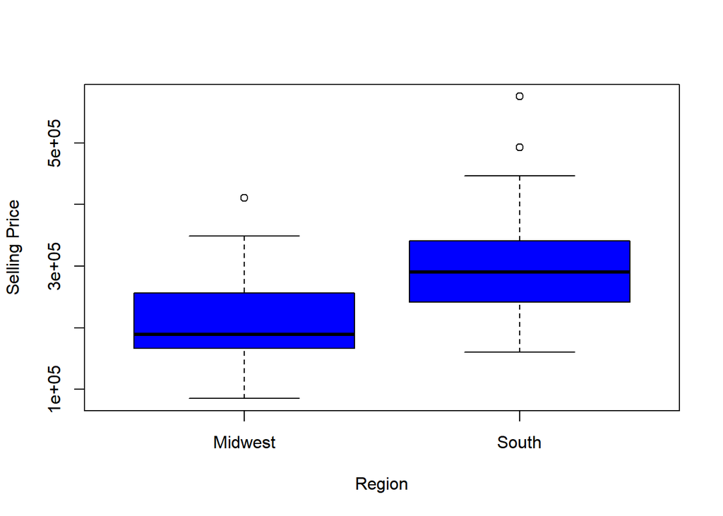

```r
boxplot(dataset$`Selling Price`~dataset$Region,
        xlab = "Region",
        ylab = "Selling Price",
        col = "Blue",
        border = "Black")
```

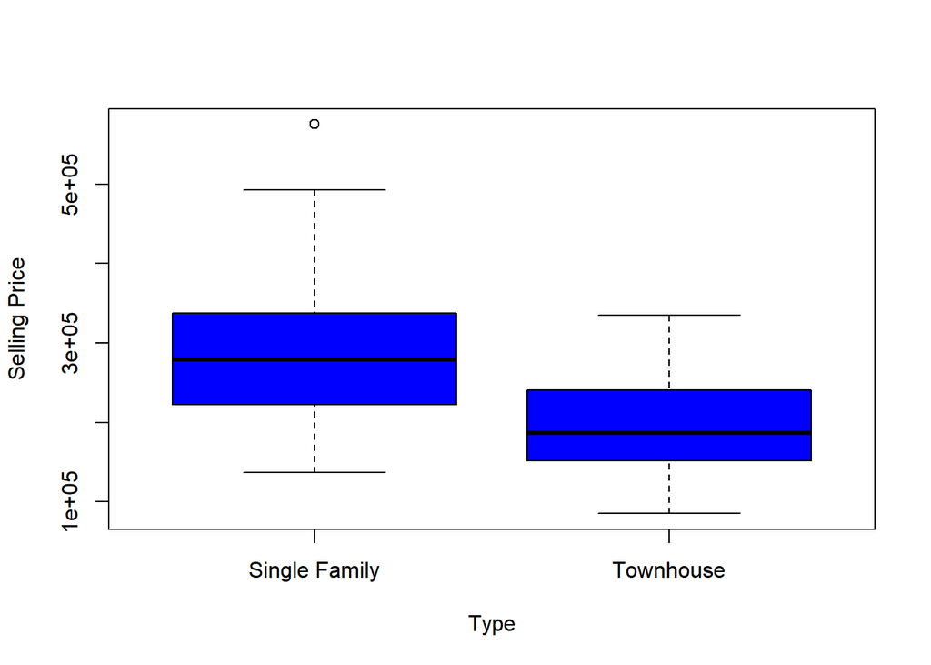

```r
boxplot(dataset$`Selling Price`~dataset$Type,
        xlab = "Type",
        ylab = "Selling Price",
        col = "Blue",
        border = "Black")
```

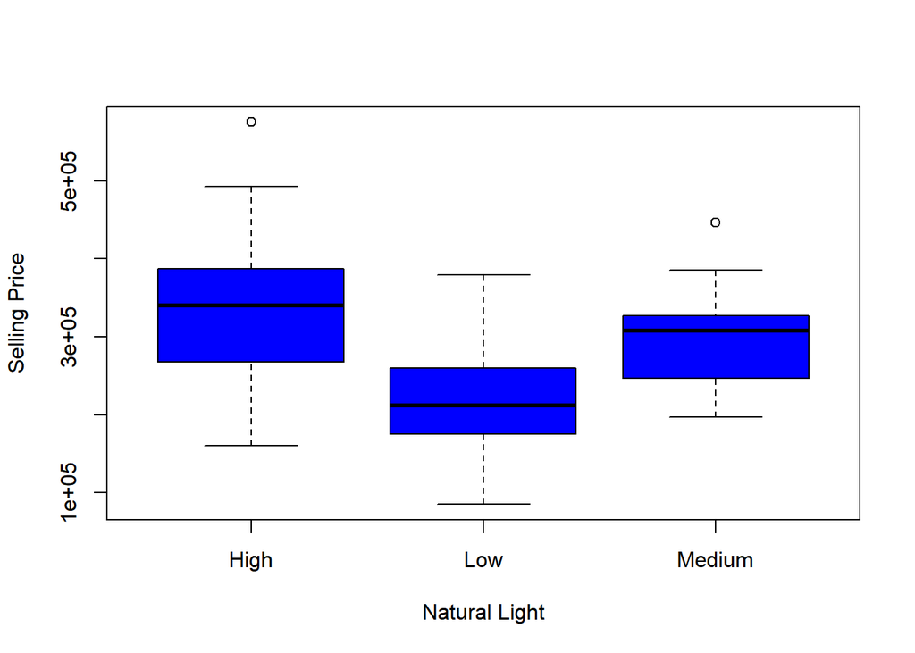

```r
boxplot(dataset$`Selling Price`~dataset$NaturalLight,
        xlab = "Natural Light",
        ylab = "Selling Price",
        col = "Blue",
        border = "Black")
```

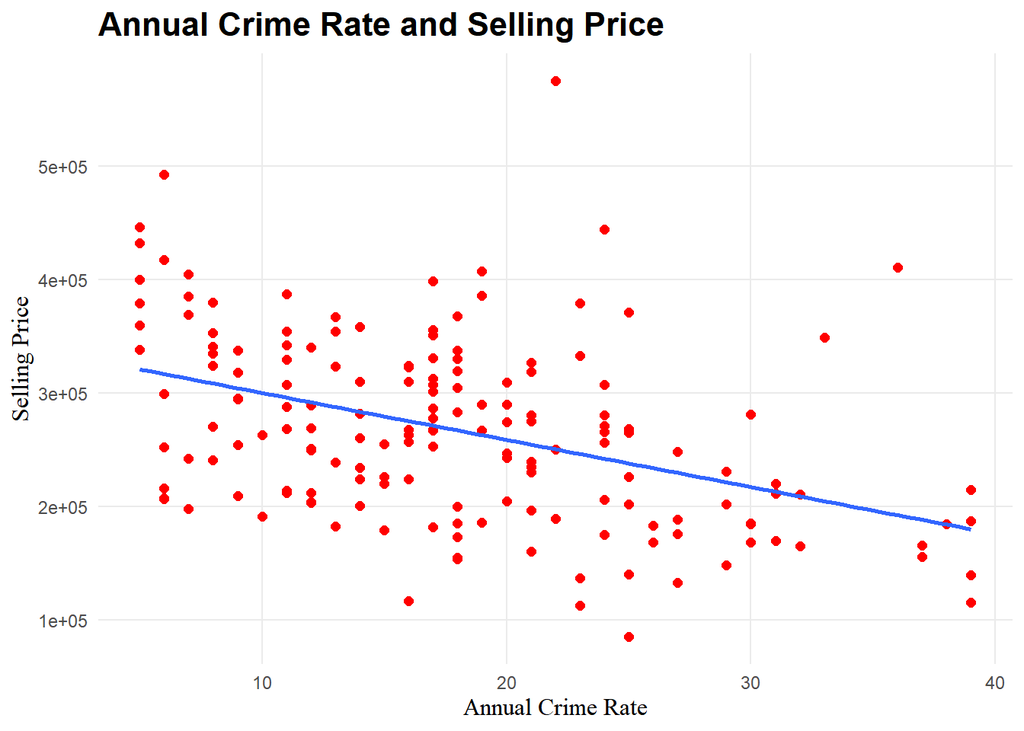

```r
ggplot(data = dataset,aes(x = AnnualCrimeRate, y = `Selling Price`)) +
  geom_point(color = "red", size = 2) +
  geom_smooth(method="lm", se = FALSE) +
  theme_minimal() +
  labs(title="Annual Crime Rate and Selling Price", x="Annual Crime Rate", y="Selling Price") +
  theme(
    plot.title = element_text(size = 16, face = "bold"),
    axis.title = element_text(size = 12, family ="serif"),
    panel.grid.minor = element_blank()
    )
```

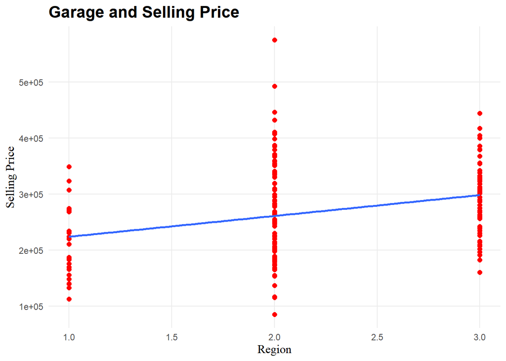

```r
ggplot(data = dataset,aes(x = Garage, y = `Selling Price`)) +
  geom_point(color = "red", size = 2) +
  geom_smooth(method="lm", se = FALSE) +
  theme_minimal() +
  labs(title="Garage and Selling Price", x="Region", y="Selling Price") +
  theme(
    plot.title = element_text(size = 16, face = "bold"),
    axis.title = element_text(size = 12, family ="serif"),
    panel.grid.minor = element_blank()
    )
```

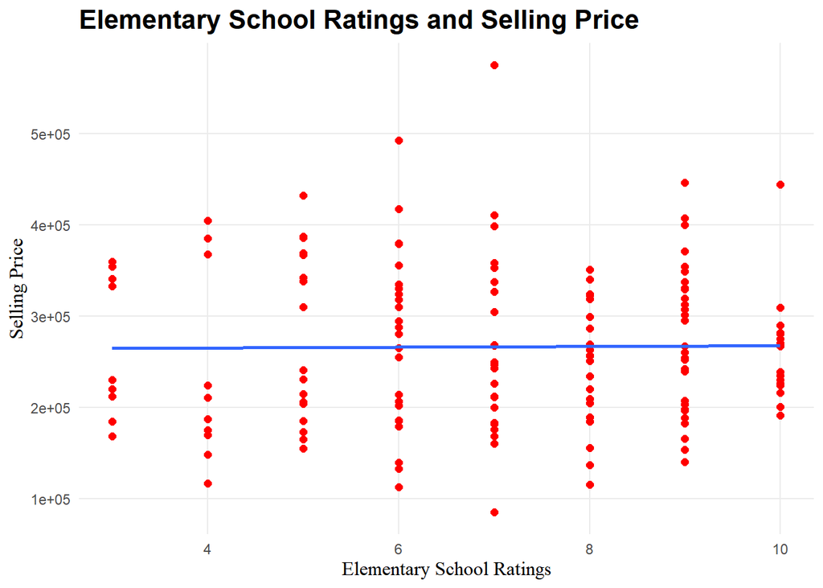

```r
ggplot(data = dataset,aes(x = ElemSchoolRatings, y = `Selling Price`)) +
  geom_point(color = "red", size = 2) +
  geom_smooth(method="lm", se = FALSE) +
  theme_minimal() +
  labs(title="Elementary School Ratings and Selling Price", x="Elementary School Ratings", y="Selling Price") +
  theme(
    plot.title = element_text(size = 16, face = "bold"),
    axis.title = element_text(size = 12,family ="serif"),
    panel.grid.minor = element_blank()
    )
```

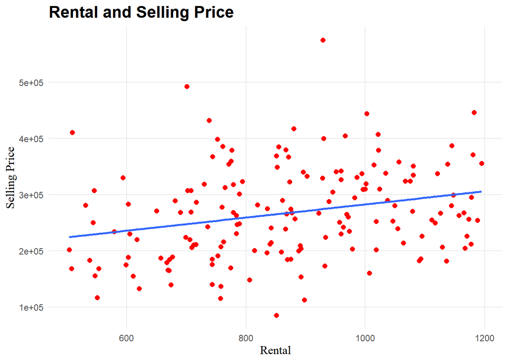

```r
ggplot(data = dataset,aes(x = Rental, y = `Selling Price`)) +
  geom_point(color = "red", size = 2) +
  geom_smooth(method="lm",se = FALSE) +
  theme_minimal() +
  labs(title="Rental and Selling Price", x="Rental", y="Selling Price") +
  theme(
    plot.title = element_text(size = 16, face = "bold"),
    axis.title = element_text(size = 12, family ="serif"),
    panel.grid.minor = element_blank()
    )
```

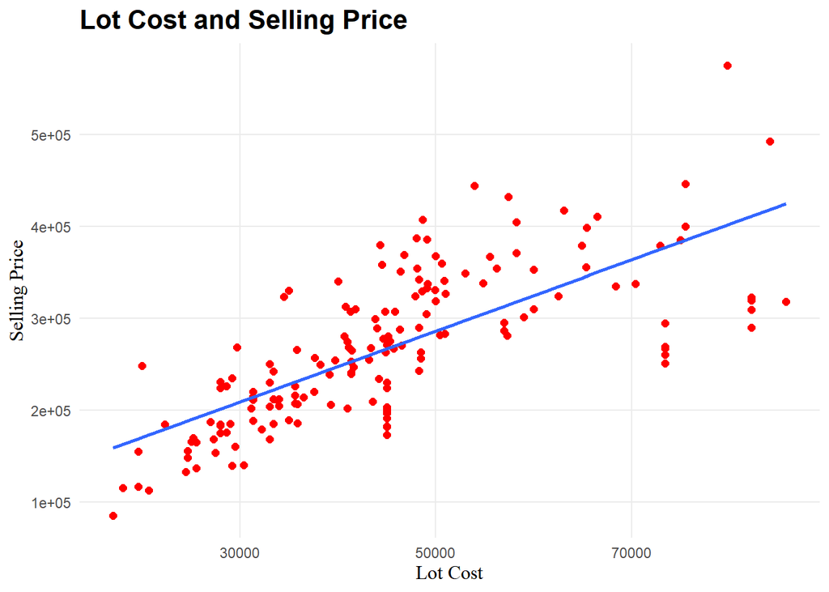

```r
ggplot(data = dataset,aes(x = `Lot Cost`, y = `Selling Price`)) +
  geom_point(color = "red", size = 2) +
  geom_smooth(method="lm", se = FALSE) +
  theme_minimal() +
  labs(title="Lot Cost and Selling Price", x="Lot Cost", y="Selling Price") +
  theme(
    plot.title = element_text(size = 16, face = "bold"),
    axis.title = element_text(size = 12, family ="serif"),
    panel.grid.minor = element_blank()
    )
```

### STEP 2 Correlation

#### Correlation Matrix

```r
dataset$Region[dataset$Region == "South"] <- 1
dataset$Region[dataset$Region == "Midwest"] <- 2

dataset$Type[dataset$Type == "Single Family"] <- 1
dataset$Type[dataset$Type == "Townhouse"] <- 2

dataset$NaturalLight[dataset$NaturalLight == "Low"] <- 1
dataset$NaturalLight[dataset$NaturalLight == "Medium"] <- 2
dataset$NaturalLight[dataset$NaturalLight == "High"] <- 3

dataset %<>%
    mutate_each(funs(if(is.character(.)) as.numeric(.) else .))

corr_mat= cor(dataset[,c("Selling Price","Region","Type","NaturalLight","AnnualCrimeRate","Garage","ElemSchoolRatings","Rental","Lot Cost")], use="complete")
corr_mat
```

```
##                   Selling Price     Region        Type NaturalLight
## Selling Price        1.00000000 -0.5569444 -0.43370799   0.59303870
## Region              -0.55694444  1.0000000  0.23950803  -0.30996972
## Type                -0.43370799  0.2395080  1.00000000  -0.26488235
## NaturalLight         0.59303870 -0.3099697 -0.26488235   1.00000000
## AnnualCrimeRate     -0.42774224  0.6425387  0.12802461  -0.19165437
## Garage               0.33273756 -0.6439357 -0.26205532   0.17611544
## ElemSchoolRatings    0.00969382 -0.3352968  0.00962726  -0.06367728
## Rental               0.28489665 -0.6369271 -0.10923720   0.10189271
## Lot Cost             0.74161148 -0.5970676 -0.11603195   0.44685742
##                   AnnualCrimeRate     Garage ElemSchoolRatings     Rental
## Selling Price         -0.42774224  0.3327376        0.00969382  0.2848966
## Region                 0.64253866 -0.6439357       -0.33529681 -0.6369271
## Type                   0.12802461 -0.2620553        0.00962726 -0.1092372
## NaturalLight          -0.19165437  0.1761154       -0.06367728  0.1018927
## AnnualCrimeRate        1.00000000 -0.4185553       -0.08601028 -0.3947465
## Garage                -0.41855526  1.0000000        0.26110959  0.3556407
## ElemSchoolRatings     -0.08601028  0.2611096        1.00000000  0.2241394
## Rental                -0.39474653  0.3556407        0.22413936  1.0000000
## Lot Cost              -0.43730622  0.3719957        0.19420476  0.2942523
##                     Lot Cost
## Selling Price      0.7416115
## Region            -0.5970676
## Type              -0.1160319
## NaturalLight       0.4468574
## AnnualCrimeRate   -0.4373062
## Garage             0.3719957
## ElemSchoolRatings  0.1942048
## Rental             0.2942523
## Lot Cost           1.0000000
```

### STEP 3 Regression Model

In this step, a model was established for the given data to predict selling price of the house. The summary of the model was used to get a measure of how feasible our model is. Two values from the summary were of main concern, the p-value and the adjusted R-squared value. After trying out different models, the following model was selected. This model gave a R squared value of 0.372 and a p-value of less than 0.05.

#### Modelling and Summary

```r
model1 <- lm(`Selling Price` ~ Region + Type + AnnualCrimeRate, data = dataset)
summary(model1)
```

```
##
## Call:
## lm(formula = `Selling Price` ~ Region + Type + AnnualCrimeRate,
##     data = dataset)
##
## Residuals:
##     Min      1Q  Median      3Q     Max
## -133537  -47569   -1294   36849  283437
##
## Coefficients:
##                 Estimate Std. Error t value Pr(>|t|)
## (Intercept)     460321.7    20015.5  22.998  < 2e-16 ***
## Region          -55104.4    13509.2  -4.079 7.04e-05 ***
## Type            -72727.3    13008.7  -5.591 9.26e-08 ***
## AnnualCrimeRate  -1854.9      756.2  -2.453   0.0152 *
## ---
## Signif. codes:  0 '***' 0.001 '**' 0.01 '*' 0.05 '.' 0.1 ' ' 1
##
## Residual standard error: 65130 on 164 degrees of freedom
## Multiple R-squared:  0.3833, Adjusted R-squared:  0.372
## F-statistic: 33.98 on 3 and 164 DF,  p-value: < 2.2e-16
```

### STEP 4 Non-Linearity

In this step, the crPlot() command was used to test the non-linearity of the residuals. Since the distance between the residual line and the component line was not significant, it was assumed that predictors have a linear relationship with the dependent variable. The plot is shown below the code chunk.

#### Testing for Non-Linearity

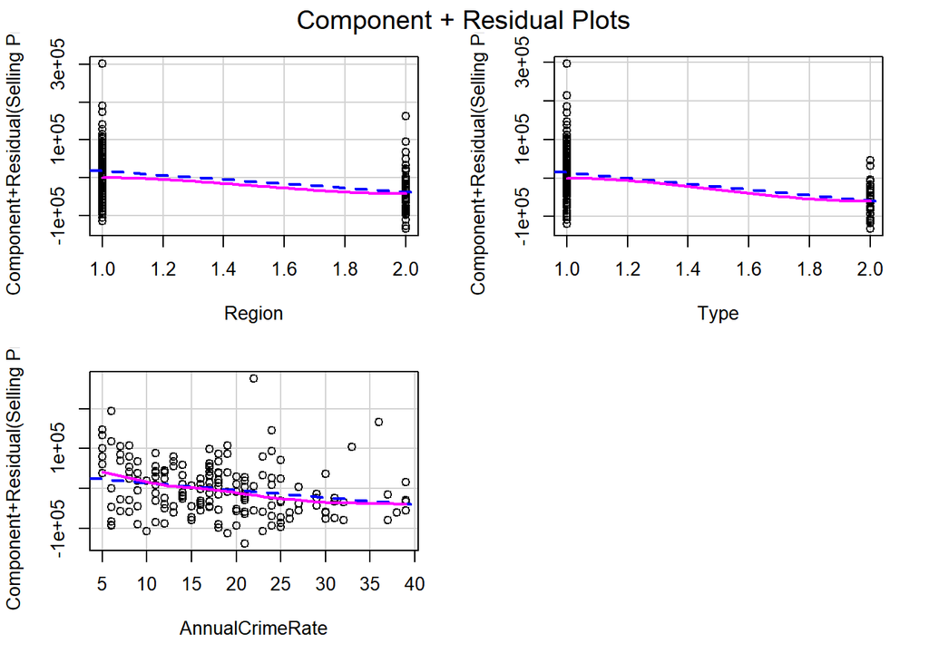

```r
crPlots(model1)
```

### STEP 5 Non-Normality

#### Testing for Non-Normality

This step included testing for non-normality of the residuals. The points deviate from the line, therefore, we can say that there is some non-normality in the model. The distribution of the studentized residuals show that most of the data can be assumed normal, if the outlier is not taken into consideration.

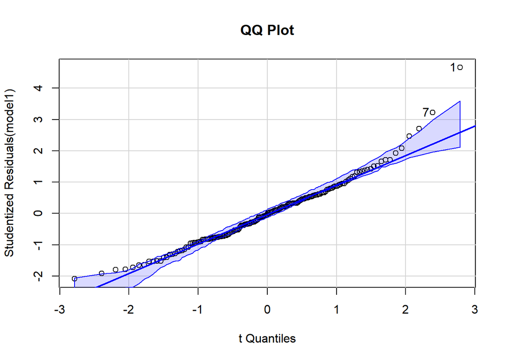

```
## [1] 1 7
```

```r
qqPlot(model1, main="QQ Plot")
```

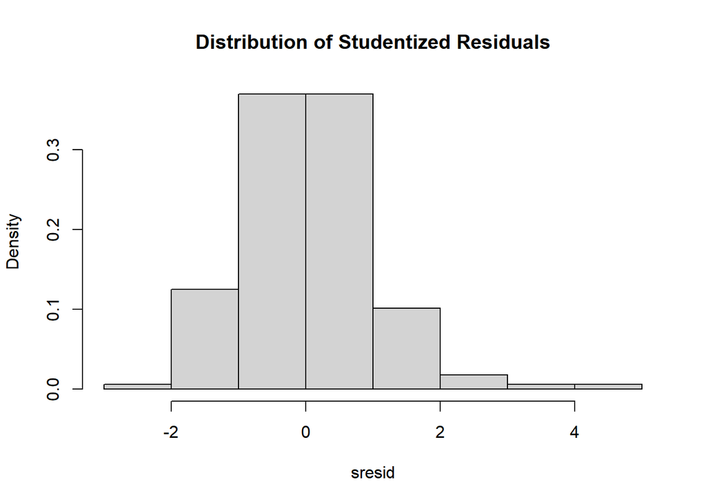

```r
sresid <- studres(model1)
hist(sresid, freq=FALSE, main="Distribution of Studentized Residuals")
```

### STEP 6 HOMOSCEDASTICITY

This step involved testing for homoscedasticity. For this model, the p-value is 0.014, which is less than 0.05. Therefore, our model is more likely to be heteroscedastic. The spread graph below confirms the model to be heteroscedastic. But since the difference is not too much, and the R-squared value getting lower with homoscedastic results, we assumed it to be a trade-off between both values.

#### Testing for homoscdasticity

```r
ncvTest(model1)
```

```
## Non-constant Variance Score Test
## Variance formula: ~ fitted.values
## Chisquare = 6.012578, Df = 1, p = 0.014204
```

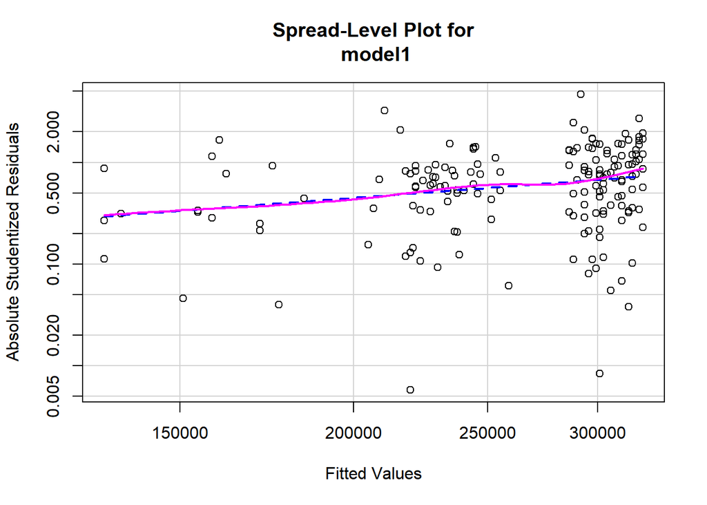

```
##
## Suggested power transformation:  -0.006971636
```

```r
spreadLevelPlot(model1)
```

### STEP 7 INFLUENCE PLOT

In this step, the influence plot was obtained as shown below:

#### Influence plot

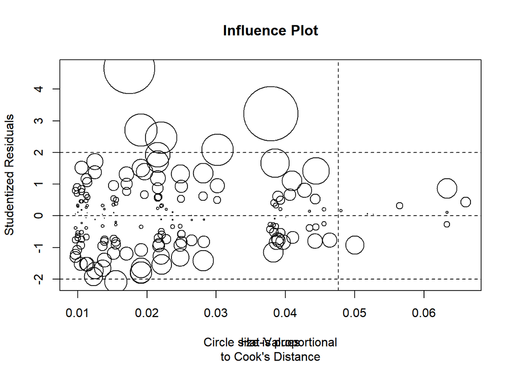

```r
influencePlot(model1, id.method="identify", main="Influence Plot", sub="Circle size is proportional
to Cook's Distance", id=list(method="identify") )
```

### STEP 8 MULTICOLLINEARITY

The last step for the model was used to get a measure of multicollinearity in the model. Since the Vifs are smaller than 4, we can assume that there is no multicollinearity in the model.

#### Testing for multicollinearity

```r
vif(model1)
```

```
##          Region            Type AnnualCrimeRate
##        1.591470        1.033369        1.564926
```

For the residuals, the crPlot showed almost overlapping residual and component lines, and the distance between residuals and line in QQ plot was not significant. The distribution plot shows the data to be almost normal, and the reported p-value for the residuals was greater than 0.05. The Vifs were also less than 4, so all the assumptions pointed towards a better model for predicting house prices.

The codes and the plots of this model are shown below. The steps followed are similar to the case in the first model.

```r
dataset<-log(dataset)
```

```r
model1 <- lm(`Selling Price` ~ Type + `Lot Cost` + NaturalLight+ AnnualCrimeRate, data = dataset)
summary(model1)
```

```
##
## Call:
## lm(formula = `Selling Price` ~ Type + `Lot Cost` + NaturalLight +
##     AnnualCrimeRate, data = dataset)
##
## Residuals:
##      Min       1Q   Median       3Q      Max
## -0.38296 -0.08872 -0.00034  0.09441  0.36338
##
## Coefficients:
##                 Estimate Std. Error t value Pr(>|t|)
## (Intercept)      6.67144    0.47722  13.980  < 2e-16 ***
## Type            -0.35960    0.04483  -8.021 1.94e-13 ***
## `Lot Cost`       0.55451    0.04204  13.190  < 2e-16 ***
## NaturalLight     0.14906    0.02887   5.164 6.97e-07 ***
## AnnualCrimeRate -0.05794    0.02571  -2.254   0.0255 *
## ---
## Signif. codes:  0 '***' 0.001 '**' 0.01 '*' 0.05 '.' 0.1 ' ' 1
##
## Residual standard error: 0.1524 on 163 degrees of freedom
## Multiple R-squared:  0.7795, Adjusted R-squared:  0.7741
## F-statistic: 144.1 on 4 and 163 DF,  p-value: < 2.2e-16
```

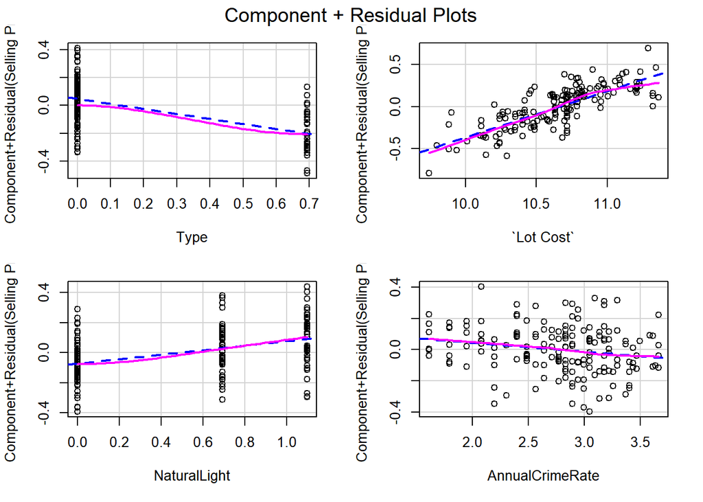

```r
crPlots(model1)
```

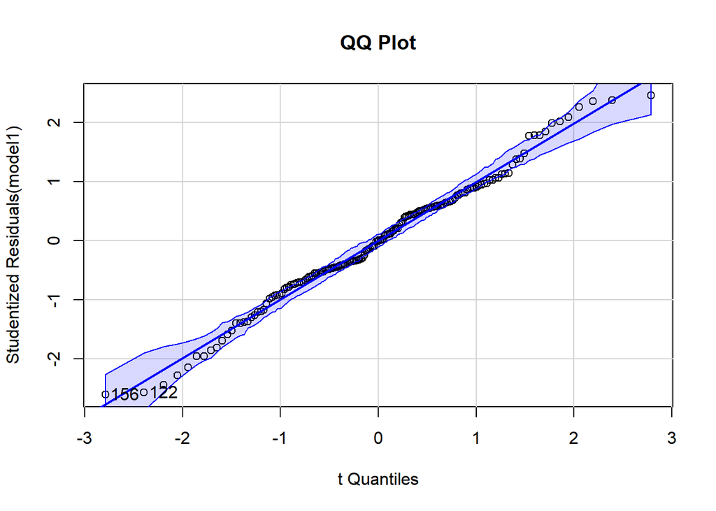

```
## [1] 122 156
```

```r
qqPlot(model1, main="QQ Plot")
```

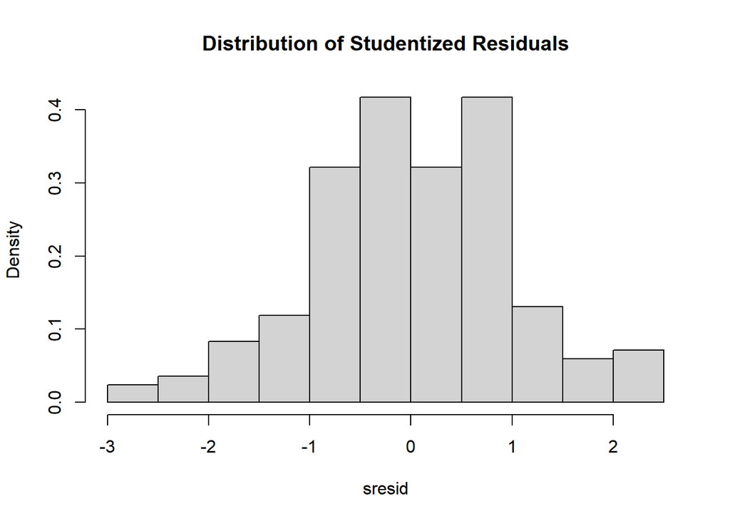

```r
sresid <- studres(model1)
hist(sresid, freq=FALSE, main="Distribution of Studentized Residuals")
```

```r
ncvTest(model1)
```

```
## Non-constant Variance Score Test
## Variance formula: ~ fitted.values
## Chisquare = 0.01001395, Df = 1, p = 0.92029
```

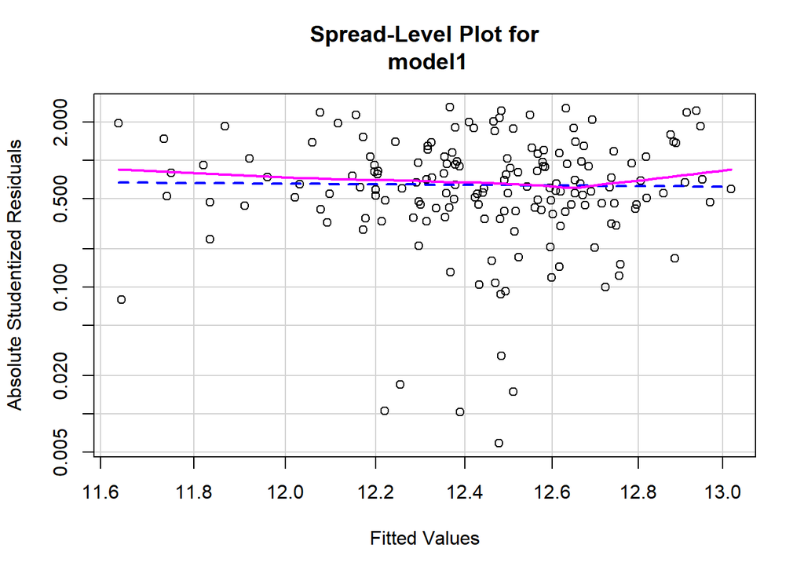

```
##
## Suggested power transformation:  1.746698
```

```r
spreadLevelPlot(model1)
```

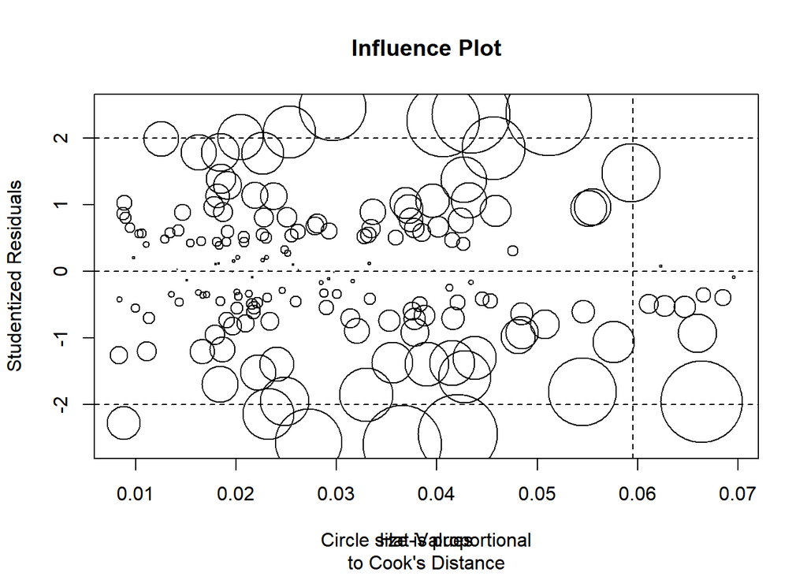

```r
influencePlot(model1, id.method="identify", main="Influence Plot", sub="Circle size is proportional
to Cook's Distance", id=list(method="identify") )
```

```r
vif(model1)
```

```
##            Type      `Lot Cost`    NaturalLight AnnualCrimeRate
##        1.076604        1.510796        1.295430        1.258561
```